# Data

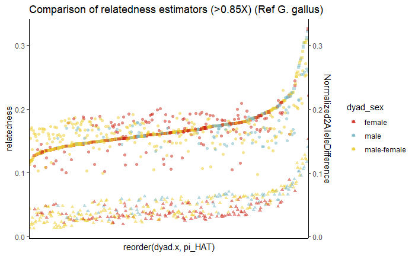

```r
theme_set(theme_classic())

#plot relatedness pi_HAT and rab (y-axis) for every dyad (x-axis), ordered from low to high relatedness and colored according to inter- or intragroup dyad

ggplot(filter(relate_results_gg, coverage > 0.85), aes(x = reorder(dyad.x, pi_HAT), color = dyad_sex)) +

  scale_colour_manual(values = three_colors) +

  geom_point(alpha = 0.5, aes(y = pi_HAT), shape = 15) + #plot lcmlkin relatedness estimates as points

  geom_point(alpha = 0.5, aes(y = 1.2-Normalized2AlleleDifference), shape = 16) + #plot READ estimate

  geom_point(alpha = 0.5, aes(y = rab), shape = 17) + # plot ngsRelate estimates

  theme(axis.text.x = element_blank(), axis.ticks.x = element_blank()) +

  scale_y_continuous(

    name = "relatedness", #features of first axis

    sec.axis = sec_axis(~., name = "Normalized2AlleleDifference") #features of second axis
  ) +

  ggtitle("Comparison of relatedness estimators (>0.85X) (Ref G. gallus)")
```

```r
NA
NA
```

Compare correlation among the three estimators

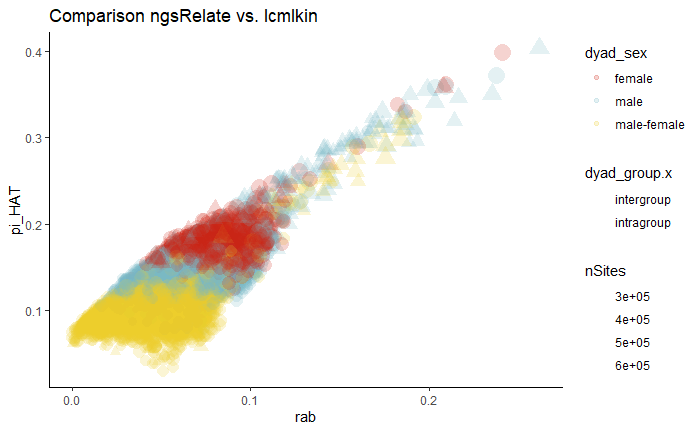

```r
ggplot(relate_results, aes(x = rab, y = pi_HAT, color = dyad_sex, size = nSites, shape = dyad_group.x)) +

  scale_colour_manual(values = three_colors, na.value = 1) +

   geom_point(alpha = 0.2) +

  ggtitle("Comparison ngsRelate vs. lcmlkin")
```

```r
NA
NA
```

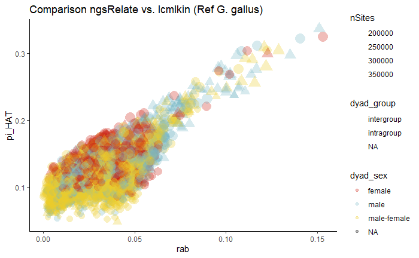

```r
ggplot(relate_results_gg, aes(x = rab, y = pi_HAT, color = dyad_sex, size = nSites, shape = dyad_group)) +

  scale_colour_manual(values = three_colors, na.value = 1) +

   geom_point(alpha = 0.3) +

  ggtitle("Comparison ngsRelate vs. lcmlkin (Ref G. gallus)")
```

```r
NA
NA
```

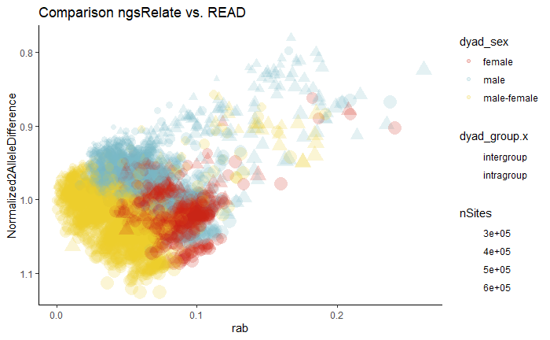

```r
ggplot(relate_results, aes(x = rab, y = Normalized2AlleleDifference, color = dyad_sex, size = nSites, shape = dyad_group.x)) +

  scale_colour_manual(values = three_colors, na.value = 1) +

  geom_point(alpha = 0.2) +

  scale_y_continuous(trans = "reverse") +

  ggtitle("Comparison ngsRelate vs. READ")
```

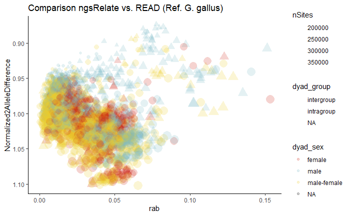

```r
ggplot(relate_results_gg, aes(x = rab, y = Normalized2AlleleDifference, color = dyad_sex, size = nSites, shape = dyad_group)) +

  scale_colour_manual(values = three_colors, na.value = 1) +

  geom_point(alpha = 0.2) +

  scale_y_continuous(trans = "reverse") +

  ggtitle("Comparison ngsRelate vs. READ (Ref. G. gallus)")
```

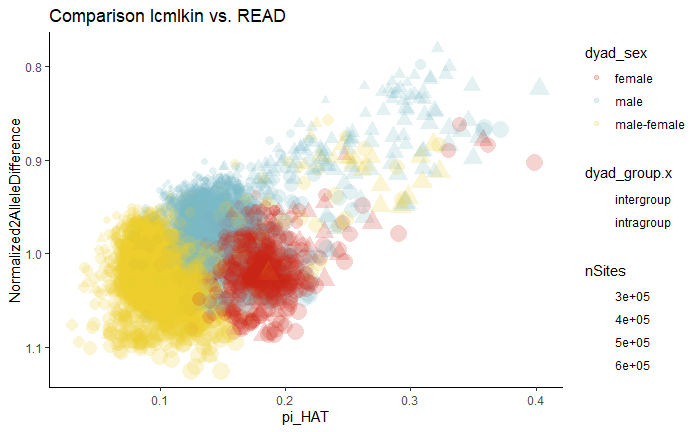

```r
ggplot(relate_results, aes(x = pi_HAT, y = Normalized2AlleleDifference, color = dyad_sex, size = nSites, shape = dyad_group.x)) +

  scale_colour_manual(values = three_colors, na.value = 1) +

  geom_point(alpha = 0.2) +

  scale_y_continuous(trans = "reverse") +

  ggtitle("Comparison lcmlkin vs. READ")
```

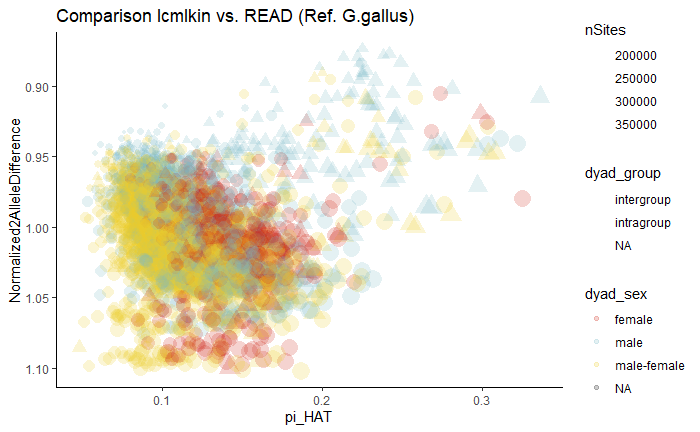

```r
ggplot(relate_results_gg, aes(x = pi_HAT, y = Normalized2AlleleDifference, color = dyad_sex, size = nSites, shape = dyad_group)) +

  scale_colour_manual(values = three_colors, na.value = 1) +

  geom_point(alpha = 0.2) +

  scale_y_continuous(trans = "reverse") +

  ggtitle("Comparison lcmlkin vs. READ (Ref. G.gallus)")
```

Comparison of mapping

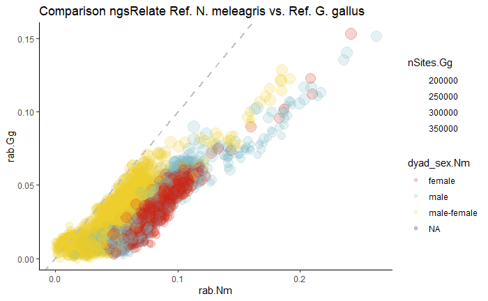

```r
ggplot(relate_results_NmGg, aes(x = rab.Nm, y = rab.Gg, color = dyad_sex.Nm, size = nSites.Gg)) +

  scale_colour_manual(values = three_colors, na.value = 1) +

  geom_point(alpha = 0.2) +

  geom_abline(intercept = 0, slope = 1, color = "grey", linetype = "dashed", size = 1) + #line showing perfect correlation

 # geom_smooth() +

  ggtitle("Comparison ngsRelate Ref. N. meleagris vs. Ref. G. gallus")
```

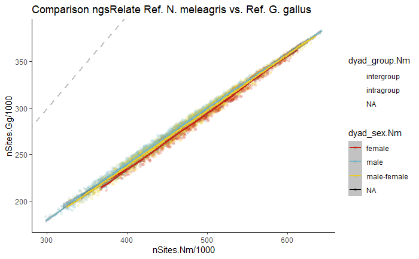

```r
ggplot(relate_results_NmGg, aes(x = nSites.Nm/1000, y = nSites.Gg/1000, color = dyad_sex.Nm, shape = dyad_group.Nm)) +

  scale_colour_manual(values = three_colors, na.value = 1) +

  geom_point(alpha = 0.2) +

  geom_smooth() +

  geom_abline(intercept = 0, slope = 1, color = "grey", linetype = "dashed", size = 1) + #line showing perfect correlation


  ggtitle("Comparison ngsRelate Ref. N. meleagris vs. Ref. G. gallus")
```

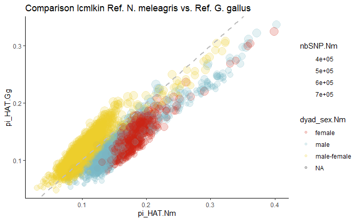

```r
ggplot(relate_results_NmGg, aes(x = pi_HAT.Nm, y = pi_HAT.Gg, color = dyad_sex.Nm, size = nbSNP.Nm)) +

  scale_colour_manual(values = three_colors, na.value = 1) +

  geom_point(alpha = 0.2) +

  geom_abline(intercept = 0, slope = 1, color = "grey", linetype = "dashed", size = 1) + #line showing perfect correlation

  # geom_smooth() +

  ggtitle("Comparison lcmlkin Ref. N. meleagris vs. Ref. G. gallus")
```

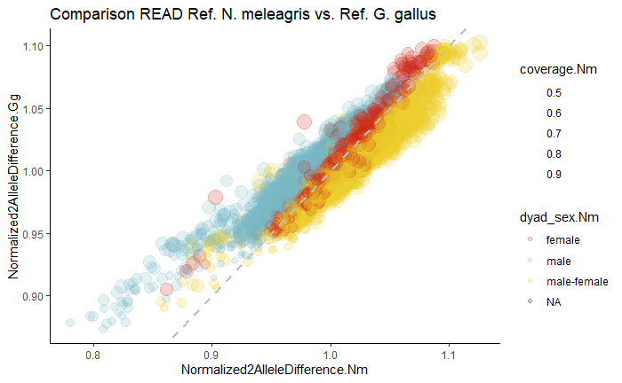

```r
ggplot(relate_results_NmGg, aes(x = Normalized2AlleleDifference.Nm, y = Normalized2AlleleDifference.Gg, color = dyad_sex.Nm, size = coverage.Nm)) +

  scale_colour_manual(values = three_colors, na.value = 1) +

  geom_point(alpha = 0.2) +

  geom_abline(intercept = 0, slope = 1, color = "grey", linetype = "dashed", size = 1) + #line showing perfect correlation


 # geom_smooth() +

  ggtitle("Comparison READ Ref. N. meleagris vs. Ref. G. gallus")
```

Have a closer look at the groups

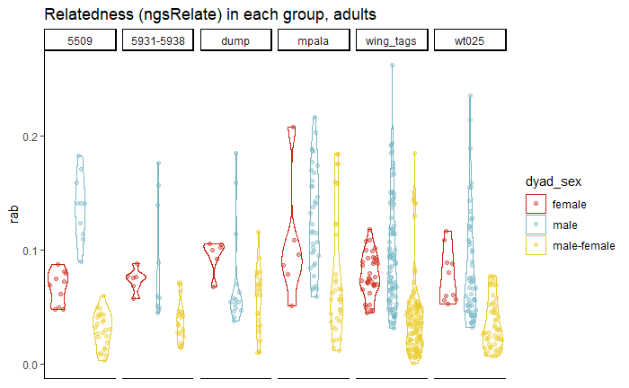

```r
ggplot(filter(relate_results, dyad_group == "intragroup", a_Group != "mpala_chicks", b_Group != "ROOP"), aes(x = dyad_sex, y = rab, color = dyad_sex)) +

  scale_color_manual(values = three_colors, na.value = 1) +

  geom_sina(alpha = 0.4) +

  geom_violin(alpha = 0) +

  facet_grid(.~a_Group) +

 theme (axis.text.x = element_blank(),
        axis.title.x = element_blank(),
        axis.ticks.x = element_blank()) +

  ggtitle("Relatedness (ngsRelate) in each group, adults")
```

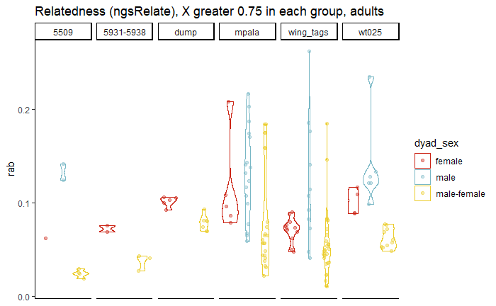

```r
ggplot(filter(relate_results, dyad_group == "intragroup", coverage > 0.75, a_Group != "mpala_chicks", b_Group != "ROOP"), aes(x = dyad_sex, y = rab, color = dyad_sex)) +

  scale_color_manual(values = three_colors, na.value = 1) +

  geom_sina(alpha = 0.4) +

  geom_violin(alpha = 0) +

  facet_grid(.~a_Group) +

 theme (axis.text.x = element_blank(),
        axis.title.x = element_blank(),
        axis.ticks.x = element_blank()) +

  ggtitle("Relatedness (ngsRelate), X greater 0.75 in each group, adults")
```

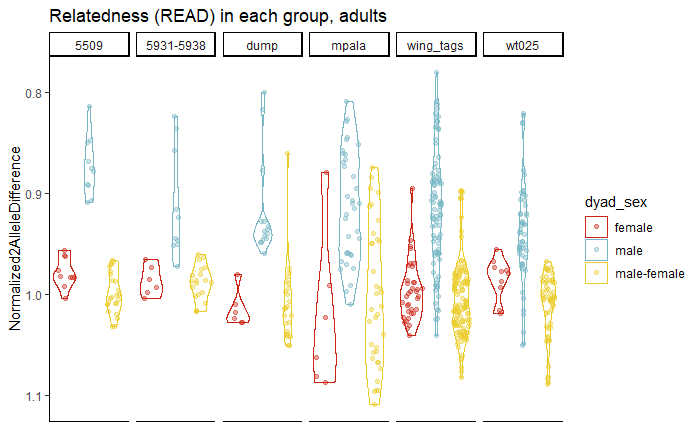

```r
ggplot(filter(relate_results, dyad_group == "intragroup", a_Group != "mpala_chicks", b_Group != "ROOP"), aes(x = dyad_sex, y = Normalized2AlleleDifference, color = dyad_sex)) +

  scale_color_manual(values = three_colors, na.value = 1) +

  geom_sina(alpha = 0.4) +

  geom_violin(alpha = 0) +

  facet_grid(.~a_Group) +

  scale_y_continuous(trans = "reverse") +

 theme (axis.text.x = element_blank(),
        axis.title.x = element_blank(),
        axis.ticks.x = element_blank()) +

  ggtitle("Relatedness (READ) in each group, adults")
```

For comparison of relatedness estimators check Yaka et al. 2021 Curr Biol.

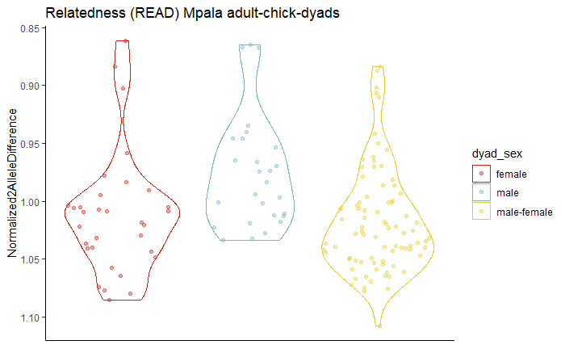

```r
ggplot(subset(relate_results, a_Group %in% c("mpala", "mpala_chicks") & b_Group %in% c("mpala", "mpala_chicks") & dyad_group %in% "intergroup"), aes(x = dyad_sex, y = Normalized2AlleleDifference, color = dyad_sex)) +

  scale_color_manual(values = three_colors, na.value = 1) +

  geom_sina(alpha = 0.4) +

  geom_violin(alpha = 0) +

  scale_y_continuous(trans = "reverse") +

  theme (axis.text.x = element_blank(),
        axis.title.x = element_blank(),
        axis.ticks.x = element_blank()) +

  ggtitle("Relatedness (READ) Mpala adult-chick-dyads")
```

investigate breeding pairs in comparision to rest

```r
#extract breeding pair rows

breeding_pair_relatedness <- filter(relate_results, !is.na(breedingpair))

#only keep dyad, rank difference and relatedness values

breeding_pair_relatedness <- select(breeding_pair_relatedness, dyad, a_sex, b_sex, rab, pi_HAT, NonNormalizedP0, breedingpair)

breeding_pair_relatedness
```

| dyad | a_sex | b_sex | rab | pi_HAT | NonNormalizedP0 | breedingpair |
| --- | --- | --- | --- | --- | --- | --- |
| W1278-W1294 | m | f | 0.056424 | 0.138 | 0.3961295 | breeding_pair |
| A1316-W1545 | m | f | 0.051948 | 0.075 | 0.3658711 | breeding_pair |
| A1316-W1309 | m | f | 0.052366 | 0.076 | 0.3660741 | breeding_pair |
| W1273-W1287 | m | f | 0.011792 | 0.090 | 0.3565621 | breeding_pair |
| W1272-W1287 | f | m | 0.020269 | 0.084 | 0.3545953 | breeding_pair |
| W1289-W1294 | f | m | 0.175439 | 0.276 | 0.3391174 | breeding_pair |
| W1272-W1279 | f | m | 0.054461 | 0.077 | 0.3749421 | breeding_pair |
| W1279-W1291 | f | m | 0.158553 | 0.261 | 0.3254995 | breeding_pair |
| A1298-W1546 | m | f | 0.022694 | 0.111 | 0.3668629 | breeding_pair |
| B1311-W1309 | m | f | 0.050610 | 0.096 | 0.3670897 | breeding_pair |

```r
NA
NA
```

```
Tried to calculate with group_by(), but the calculation failed.
Falling back to ungrouped filter operation...Tried to calculate with group_by(), but the calculation failed.
Falling back to ungrouped filter operation...
```

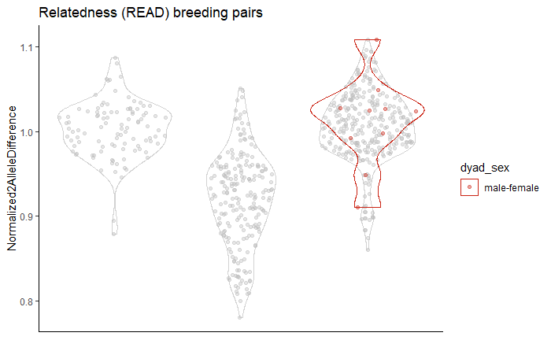

```r
ggplot(subset(relate_results, dyad_group %in% "intragroup"), aes(x = dyad_sex, y = Normalized2AlleleDifference, color = dyad_sex)) +

  scale_color_manual(values = three_colors) +

  geom_sina(alpha = 0.4) +

  geom_violin(alpha = 0) +

  gghighlight(!is.na(breedingpair)) +

  #scale_y_continuous(limits = c(0.4, 0.28), n.breaks = 4, trans = "reverse") +

  theme (axis.text.x = element_blank(),
        axis.title.x = element_blank(),
        axis.ticks.x = element_blank()) +

  ggtitle("Relatedness (READ) breeding pairs")
```

investigate relatedness in dominance hierarchy

```r
str(dominance_dyads)
```

```
List of 3
 $ : tibble [91 x 8] (S3: tbl_df/tbl/data.frame)
  ..$ RankDiff                   : int [1:91] 9 10 4 3 5 7 8 2 5 14 ...
  ..$ dyad                       : chr [1:91] "D4714-W1272" "D4714-W1273" "D4714-W1278" "D4714-W1279" ...
  ..$ rab                        : num [1:91] 0.0974 0.1557 0.1888 0.1602 0.0471 ...
  ..$ pi_HAT                     : num [1:91] 0.211 0.277 0.294 0.249 0.079 0.193 0.14 0.291 0.187 0.059 ...
  ..$ Normalized2AlleleDifference: num [1:91] 0.861 0.827 0.874 0.899 0.977 ...
  ..$ coverage                   : num [1:91] 0.544 0.587 0.645 0.642 0.568 ...
  ..$ dyad_sex                   : chr [1:91] "male" "male" "male" "male-female" ...
  ..$ group                      : chr [1:91] "mpala" "mpala" "mpala" "mpala" ...
 $ : tibble [36 x 8] (S3: tbl_df/tbl/data.frame)
  ..$ RankDiff                   : int [1:36] 6 8 13 11 9 18 15 14 2 7 ...
  ..$ dyad                       : chr [1:36] "W1304-W1308" "W1304-W1309" "W1304-W1394" "W1304-W1542" ...
  ..$ rab                        : num [1:36] 0.04145 0.04653 0.00702 0.00806 0.02644 ...
  ..$ pi_HAT                     : num [1:36] 0.15 0.09 0.09 0.085 0.078 0.1 0.091 0.098 0.269 0.092 ...
  ..$ Normalized2AlleleDifference: num [1:36] 0.961 1.038 0.987 0.992 1.025 ...
  ..$ coverage                   : num [1:36] 0.656 0.72 0.635 0.653 0.711 ...
  ..$ dyad_sex                   : chr [1:36] "male" "male-female" "male-female" "male-female" ...
  ..$ group                      : chr [1:36] "wingtags" "wingtags" "wingtags" "wingtags" ...
 $ : tibble [120 x 8] (S3: tbl_df/tbl/data.frame)
  ..$ RankDiff                   : int [1:120] 4 3 15 1 1 3 6 13 9 14 ...
  ..$ dyad                       : chr [1:120] "W1318-W1319" "W1318-W1320" "W1318-W1323" "W1318-W1328" ...
  ..$ rab                        : num [1:120] 0.0744 0.0509 0.1213 0.1269 0.072 ...
  ..$ pi_HAT                     : num [1:120] 0.144 0.163 0.213 0.251 0.174 0.097 0.122 0.234 0.152 0.143 ...
  ..$ Normalized2AlleleDifference: num [1:120] 0.956 0.969 1.02 0.882 0.991 ...
  ..$ coverage                   : num [1:120] 0.617 0.717 0.845 0.635 0.779 ...
  ..$ dyad_sex                   : chr [1:120] "male" "male" "male" "male" ...
  ..$ group                      : chr [1:120] "wt025" "wt025" "wt025" "wt025" ...
```

Combine dominance data

```r
#add column for group
dominance_relatedness_mpala$group <- "mpala"
dominance_relatedness_wingtags$group <- "wingtags"
dominance_relatedness_wt025$group <- "wt025"

dominance_relatedness <- rbind(dominance_relatedness_mpala, dominance_relatedness_wingtags, dominance_relatedness_wt025)
```

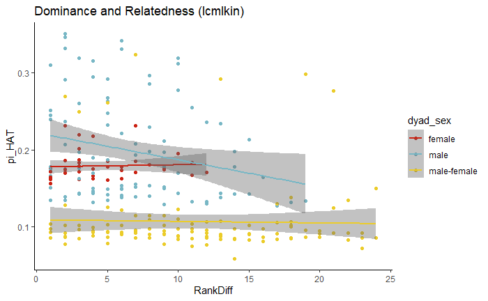

```r
ggplot(dominance_relatedness, aes(x = RankDiff, y = pi_HAT, color = dyad_sex)) +

  scale_color_manual(values = three_colors) +

  geom_point() +

  geom_smooth(method = "lm") +


  ggtitle("Dominance and Relatedness (lcmlkin)")
```

```r
NA
NA
NA
```

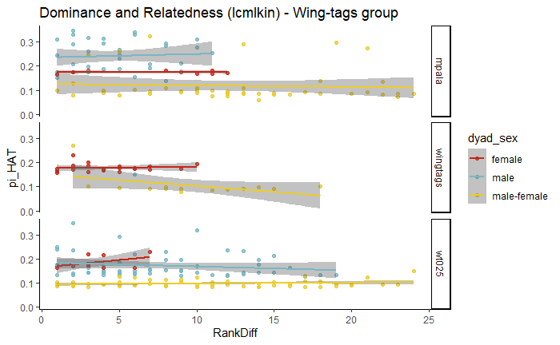

```r
ggplot(dominance_relatedness, aes(x = RankDiff, y = pi_HAT, color = dyad_sex)) +

  scale_color_manual(values = three_colors) +

  geom_point(alpha = 0.8) +

  geom_smooth(method = "lm") +

  facet_grid(group~.) +

  ggtitle("Dominance and Relatedness (lcmlkin) - Wing-tags group")
```

```r
NA
NA
NA
```

investigate influence of coverage on relatedness

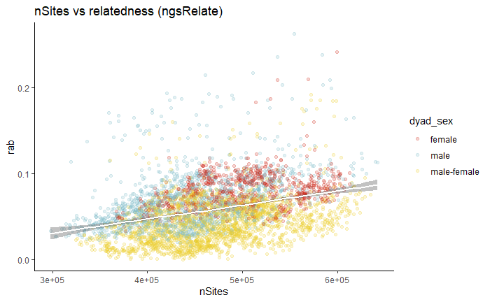

```r
ggplot(relate_results, aes(x = nSites, y = rab, colour = dyad_sex)) +

  scale_color_manual(values = three_colors) +

  geom_point(alpha = 0.2) +

  geom_smooth(colour = "white") +


  ggtitle("nSites vs relatedness (ngsRelate)")
```

this shows that ngsRelate relatedness estimates are influenced by coverage as there is an increase with nSites!

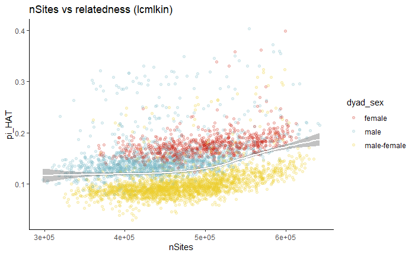

```r
ggplot(relate_results, aes(x = nSites, y = pi_HAT, colour = dyad_sex)) +

  scale_color_manual(values = three_colors) +

  geom_point(alpha = 0.2) +

  geom_smooth(colour = "white") +


  ggtitle("nSites vs relatedness (lcmlkin)")
```

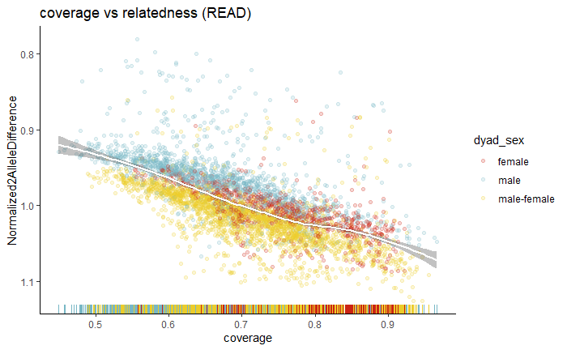

```r
ggplot(relate_results, aes(x = coverage, y = Normalized2AlleleDifference, colour = dyad_sex)) +

  scale_color_manual(values = three_colors) +

  geom_point(alpha = 0.2) +

  geom_smooth(colour = "white") +

  scale_y_continuous(trans = "reverse") +

  geom_rug(sides = "b", show.legend = FALSE) +


  ggtitle("coverage vs relatedness (READ)")
```

investigate correlation between nSites and coverage

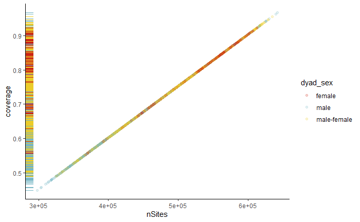

```r
ggplot(relate_results, aes(x = nSites, y = coverage, colour = dyad_sex)) +

  scale_color_manual(values = three_colors) +

  geom_point(alpha = 0.2) +

  geom_rug(sides = "l", show.legend = FALSE)
```

```r
  #geom_smooth(colour = "white") +


  ggtitle("nSites vs coverage")
```

```
$title
[1] "nSites vs coverage"

attr(,"class")
[1] "labels"
```